# Predicting the price of Diamonds

### Three-Variable Visualisation

#### Barplot of Price by Cut and Clarity

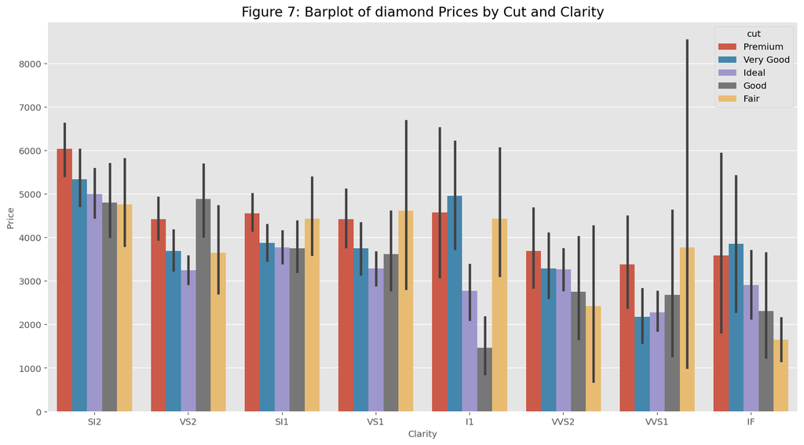

```python
plt.figure(figsize = (15,8))
fig_4 = sns.barplot(x ='clarity', y ='price', hue = 'cut', data = df)
plt.title('Figure 7: Barplot of diamond Prices by Cut and Clarity', fontsize = 15)
plt.xlabel('Clarity', fontsize = 10)
plt.ylabel('Price', fontsize = 10)
```

#### Boxplot of Price broken down by Cut and Color

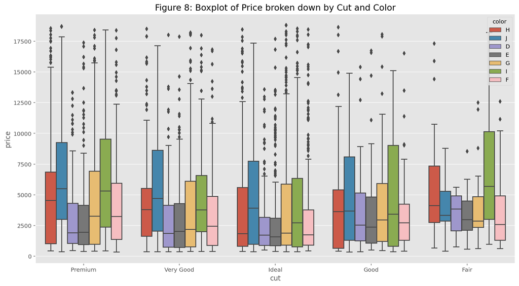

```python
plt.figure(figsize = (15,8))
sns.boxplot(df['cut'], df['price'],
            hue = df['color'])
plt.title('Figure 8: Boxplot of Price broken down by Cut and Color', fontsize = 15)
plt.show();
```

#### Scatterplot of Price by Carat colored by Cut

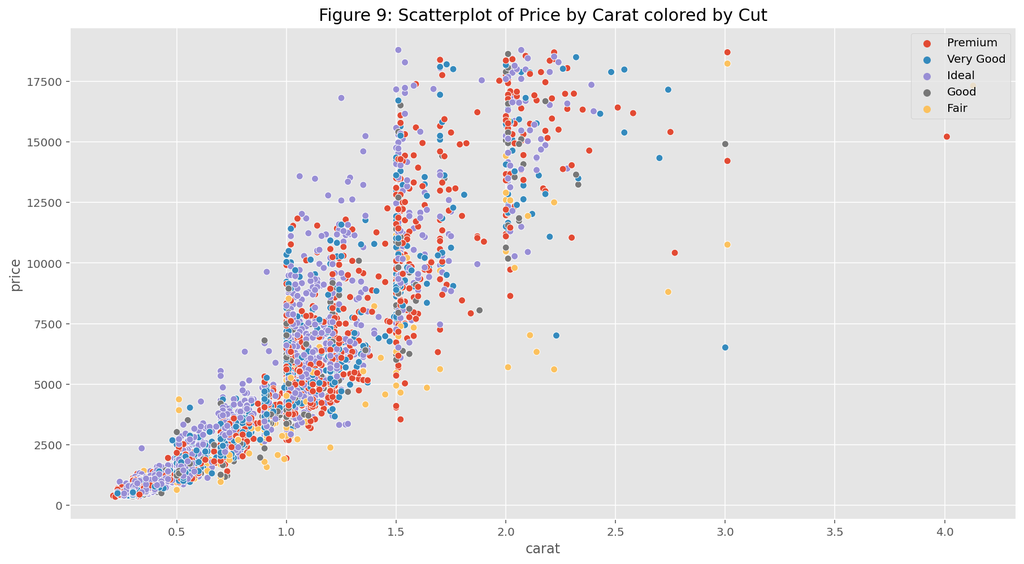

```python
plt.figure(figsize = (15,8))
sns.scatterplot(df['carat'], df['price'], hue = df['cut'])
plt.title('Figure 9: Scatterplot of Price by Carat colored by Cut', fontsize = 15);
plt.legend(loc = 'upper right')
plt.show();
```

We have already established in Figure 4 that carat and price have an exponential relationship. According to Figure 9, no distinguishable pattern can be identified for `Premium`, `Ideal`, or `Very Good` cuts. `Fair` cut diamonds are observed to have lower prices in general. `Ideal` cut diamonds seem to be the most popular cut in diamonds sold as majority of the dots are purple.

## Literature Review

Abstract: Contrary to popular belief, diamonds aren't as rare as people think. There are several factors that affect the price of diamond; however, rarity is not one of them. The price of a diamond is calculated based on its carat, cut, color and clarity, known as the four Cs of diamonds. Other features to consider include depth, table and fluorescence. Market demand also plays a significant role. This paper analyses the aforementioned features and why they are important in determining the price of a diamond.

Introduction:

Diamonds have been considered a sign of power, wealth and status for decades. They were initially believed to be extremely rare and hence had high prices. However, they are actually the most commonly found stone compared to the availability of other precious stones. "More people own diamonds than other gemstones because diamonds are so common." (Moore, 2020)This review will focus on how the dimensions and appearances of diamonds determines its price. It also aims to shine a light on how market demand is perhaps one of the more important factors to consider behind the steep prices of diamonds.

The weight of diamonds is measured in carats. The carat weight of a diamond affects the price exponentially. However, a higher carat doesn't necessarily mean that the diamond will be expensive. The cut of a diamond portrays the shape of the diamond, which in turn affects its brilliance. Lower clarity or differences in cut might change the expected price drastically. "A jump from slightly included stones (SI) to very slightly included stones (VS) isn't going to be colossal. But as soon as you reach the VVS or IF levels, prices start to follow a steep curve and rise in a staggering manner." (Gian, 2018). On the other hand, price jumps across diamonds of different colors aren't as drastic.

The depth of a diamond is the height, which is measured in millimeters. However, the depth percentage is often what is being referred to rather than the height itself. The depth percentage of a diamond represents how deep the diamond is relative to its width. Similarly, table is a percentage feature which depicts the width of top of the diamond relative to its widest point. The depth percentage and table of a diamond varies based on its cut. Similar percentages might make an 'Ideal' cut diamond look attractive while it might be disastrous for a 'Premium' cut diamond. (Gian, 2018) These percentages affect a diamond's price because they represent how light is refracted within the diamond and reach the observer's eye. Since 1999, the diamond company, De Beers, asserted that diamonds are a precious stone by restricting supply. They stockpiled diamonds and created an illusion of scarcity, thus establishing a monopoly. (Goldschein, 2011) Sales were amped up by their well-known slogan 'A diamond is forever'. Diamond suppliers ensured that diamonds were considered a luxury item to portray class and sophistication to prevent the devaluation of diamonds throughout the years (Vaillant and Wolff, 2013). The monopoly has since been dismantled but the perception of scarcity and status remains. Consequently, diamonds are still one of the most sought-after stones for engagement rings rather than emeralds, sapphires or rubies.

Conclusion:

While physical factors play a significant role in setting the price of a diamond, market demand is a feature that must be analyzed intrinsically to understand the various determinants behind the price of a diamond. Therefore, we can conclude that a regression model that can accurately determine the price of a diamond would debunk some of the myths surrounding the diamonds industry, as well as make consumption more ethical. It will also help in clearing out the misconception that diamonds are rare and hard to obtain gemstones that are priced very highly.

## Summary and Conclusion

Having a precise prediction for diamond prices can have many benefits for buyers. It can help them determine what type of diamond they want for their respective needs. A reliable model would undoubtedly help satisfy their requirements within their budget. Our goal in this project is to investigate whether we can come up with a reliable model for predicting diamond prices using the "diamonds" dataset.

In Phase I of this project, we took on the tasks of data cleaning, preprocessing and data visualisation. We decided to rename the `x`, `y`, `z` and `depth` columns to `length`, `width`, `depth` and `depth_percentage` respectively for better readability. We checked the data for any missing values and outliers. We removed rows that contained the value 0 in the `length`, `width` and `depth` columns. We chose not to remove statistical outliers because the values fall within a valid range. Moreover, the data had over 5000 rows so we sampled the data to get only 5000 random rows to save time when running models in Phase II of the project.

This report contains several data visualisations to better analyse the data. Using the descriptive variables we can see that the color 'G' seems to be the most popular among diamonds sold. Carat and price have an exponential relationship and diamonds with SI2 clarity generally have higher prices compared to diamonds with other types of clarity. Overall, premium SI2 diamonds seem to be the most expensive type. Moreover, `Ideal` cut diamonds have a higher demand according to our observations.

Some of the observations of the numerical data are skewed, including the target feature `price`. Scaling or transformation will be required to address this issue in Phase II of the project. Carat seems to be the most significant feature in determining the price of the diamond. However, further analysis is required to identify any other correlations.

## References

- ggplot2/data.R at master · tidyverse/ggplot2. (2021). Retrieved 1 October 2021, from https://github.com/tidyverse/ggplot2/blob/master/R/data.R
- stats_tutorials/Sample_Phase1_Report.ipynb at master · vaksakalli/stats_tutorials. (2021). Retrieved 2 October 2021, from https://github.com/vaksakalli/stats_tutorials/blob/master/Sample_Phase1_Report.ipynb

#### Literature Review References

- Moore, T. (2020). Are Diamonds Truly Rare? Common Diamond Myths. Retrieved 2 October 2021, from https://www.whiteflash.com/diamond-education/are-diamonds-rare/
- Gian, P. (2018). How the Diamond Clarity Scale Affects Prices (Comparison Price Chart). Retrieved 2 October 2021, from https://beyond4cs.com/clarity/how-it-affects-pricing/
- Gian, P. (2018). Diamond Depth And Table Percentages (And Why They Matter!). Retrieved 2 October 2021, from https://beyond4cs.com/grading/depth-and-table-values/
- Goldschein, E. (2011). The Incredible Story Of How De Beers Created And Lost The Most Powerful Monopoly Ever. Retrieved 2 October 2021, from https://www.businessinsider.com/history-of-de-beers-2011-12#de-beers-continued-to-post-profits-into-this-year-as-the-number-of-retail-stores-increased-worldwide-10
- Vaillant, N., & Wolff, F. (2013). Retrieved 2 October 2021, from https://halshs.archives-ouvertes.fr/halshs-00853384/document

```python
df.to_csv("cleaned_diamonds.csv", index=False)
```